# EDA Titanic - Machine Learning from Disaster

## 1. Định nghĩa vấn đề (Define Problem)

- **Mô tả**:
  - Bộ dữ liệu Titanic: Machine Learning from Disaster chứa thông tin về hành khách trên con tàu Titanic nổi tiếng bị đắm năm 1912.
  - Mục tiêu là dự đoán khả năng sống sót của hành khách dựa trên các đặc trưng cá nhân như tuổi, giới tính, hạng vé, giá vé, số người thân đi cùng,...
  - Đây là một bài toán phân loại nhị phân (binary classification), trong đó biến mục tiêu Survived có giá trị 0 (không sống sót) hoặc 1 (sống sót).
- **Dữ liệu vào**:
  - PassengerId: Id định
  - Pclass: Hạng vé (1 = hạng nhất, 2 = hạng nhì, 3 = hạng ba)
  - Name: Tên khách hàng
  - Sex: Giới tính của hành khách
  - Age: Tuổi của hành khách
  - SibSp: Số anh/chị/em hoặc vợ/chồng đi cùng
  - Parch: Số cha mẹ hoặc con cái đi cùng
  - Fare: Giá vé (bằng bảng Anh)
  - Ticket: Mã vé
  - Cabin: Số Cabin
  - Embarked: Cảng lên tàu (C = Cherbourg, Q = Queenstown, S = Southampton)
- **Kết quả**: Survived: 0 = tử vong, 1 = Sống sót

## 2. Chuẩn bị vấn đề (Prepare Problem)

### 2.1. Khai báo thư viện (Load Libraries)

```python
# Load libraries
import os, sys
from IPython import display
import numpy as np
import matplotlib.pyplot as plt
import pandas as pd
import seaborn as sns
import joblib

from sklearn.preprocessing import OneHotEncoder, LabelEncoder, OrdinalEncoder
from sklearn.preprocessing import MinMaxScaler, StandardScaler
from sklearn.model_selection import train_test_split

import warnings

%matplotlib inline
# plt.rcParams["figure.figsize"] = (12, 6)
# plt.rcParams['figure.dpi'] = 100

warnings.filterwarnings("ignore")
```

### 2.2. Nạp dữ liệu (Load Dataset)

```python
# Load dataset
data_path  = f"../data/train.csv"
df_dataset = pd.read_csv(data_path)
```

## 3. Phân tích khám phá dữ liệu (Exploration Analyze Data - EDA)

### 3.1. Thống kê mô tả (Descriptive Statistics) - Ungraphic Approach

#### (1) **Hiển thị một số thông tin về dữ liệu**

- Số dòng, số cột của dữ liệu
- Kiểu dữ liệu của từng cột
- 5 dòng đầu và 5 dòng cuối của bảng dữ liệu
- Thông tin chung về dữ liệu

```python
# shape
print(f'+ Shape: {df_dataset.shape}')
# types
print(f'+ Data Types: \n{df_dataset.dtypes}')
# head, tail
print(f'+ Contents: ')
display.display(df_dataset.head(5))
display.display(df_dataset.tail(5))
# info
df_dataset.info()
```

```
+ Shape: (891, 12)
+ Data Types:
PassengerId      int64
Survived         int64
Pclass           int64
Name            object
Sex             object
Age            float64
SibSp            int64
Parch            int64
Ticket          object
Fare           float64
Cabin           object
Embarked        object
dtype: object
+ Contents:
```

|  | PassengerId | Survived | Pclass | Name | Sex | Age | SibSp | Parch | Ticket | Fare | Cabin | Embarked |
| --- | --- | --- | --- | --- | --- | --- | --- | --- | --- | --- | --- | --- |
| 0 | 1 | 0 | 3 | Braund, Mr. Owen Harris | male | 22.0 | 1 | 0 | A/5 21171 | 7.2500 | NaN | S |
| 1 | 2 | 1 | 1 | Cumings, Mrs. John Bradley (Florence Briggs Th... | female | 38.0 | 1 | 0 | PC 17599 | 71.2833 | C85 | C |
| 2 | 3 | 1 | 3 | Heikkinen, Miss. Laina | female | 26.0 | 0 | 0 | STON/O2. 3101282 | 7.9250 | NaN | S |
| 3 | 4 | 1 | 1 | Futrelle, Mrs. Jacques Heath (Lily May Peel) | female | 35.0 | 1 | 0 | 113803 | 53.1000 | C123 | S |
| 4 | 5 | 0 | 3 | Allen, Mr. William Henry | male | 35.0 | 0 | 0 | 373450 | 8.0500 | NaN | S |

|  | PassengerId | Survived | Pclass | Name | Sex | Age | SibSp | Parch | Ticket | Fare | Cabin | Embarked |
| --- | --- | --- | --- | --- | --- | --- | --- | --- | --- | --- | --- | --- |
| 886 | 887 | 0 | 2 | Montvila, Rev. Juozas | male | 27.0 | 0 | 0 | 211536 | 13.00 | NaN | S |
| 887 | 888 | 1 | 1 | Graham, Miss. Margaret Edith | female | 19.0 | 0 | 0 | 112053 | 30.00 | B42 | S |
| 888 | 889 | 0 | 3 | Johnston, Miss. Catherine Helen "Carrie" | female | NaN | 1 | 2 | W./C. 6607 | 23.45 | NaN | S |
| 889 | 890 | 1 | 1 | Behr, Mr. Karl Howell | male | 26.0 | 0 | 0 | 111369 | 30.00 | C148 | C |
| 890 | 891 | 0 | 3 | Dooley, Mr. Patrick | male | 32.0 | 0 | 0 | 370376 | 7.75 | NaN | Q |

```
<class 'pandas.core.frame.DataFrame'>
RangeIndex: 891 entries, 0 to 890
Data columns (total 12 columns):
 #   Column       Non-Null Count  Dtype
---  ------       --------------  -----
 0   PassengerId  891 non-null    int64
 1   Survived     891 non-null    int64
 2   Pclass       891 non-null    int64
 3   Name         891 non-null    object
 4   Sex          891 non-null    object
 5   Age          714 non-null    float64
 6   SibSp        891 non-null    int64
 7   Parch        891 non-null    int64
 8   Ticket       891 non-null    object
 9   Fare         891 non-null    float64
 10  Cabin        204 non-null    object
 11  Embarked     889 non-null    object
dtypes: float64(2), int64(5), object(5)
memory usage: 83.7+ KB
```

**Nhận xét**:

- Dữ liệu bao gồm 12 cột thông tin mô tả đặc điểm của từng hành khách trên tàu Titanic như: PassengerId, Survived, Pclass, Name, Sex, Age, SibSp, Parch, Ticket, Fare, Cabin, Embarked.
- Trong đó, biến mục tiêu (target) là Survived, biểu thị trạng thái sống sót (1 = sống sót, 0 = không sống sót).
- Tổng số dòng dữ liệu là 891 dòng (ứng với 891 hành khách).
- Các cột chứa cả dữ liệu định tính (Sex, Embarked, Name, Cabin, Ticket) và định lượng (Age, Fare, SibSp, Parch), nên cần thực hiện xử lý và mã hóa phù hợp trước khi huấn luyện mô hình.
- Một số cột có thể có missing value (Age, Cabin, Embarked) nên cần kiểm tra và xử lý.

#### (2) **Kiểm tra tính toàn vẹn của dữ liệu**

- Dữ liệu có bị trùng lặp không? Hiển thị dòng bị vi phạm.
- Dữ liệu có tồn tại giá trị Null không? Hiển thị dòng bị vi phạm.
- Dữ liệu có tồn tại giá trị NaN không? Hiển thị dòng bị vi phạm.

```python
print("="*5, "Checking Null", "="*5)
display.display(df_dataset.isnull().sum())
has_null = df_dataset.isnull().sum().any()
print(f'--> Có giá trị Null: {has_null}')
if has_null:
    display.display(df_dataset[df_dataset.isnull().any(axis=1)])
```

```
===== Checking Null =====
```

```
PassengerId      0
Survived         0
Pclass           0
Name             0
Sex              0
Age            177
SibSp            0
Parch            0
Ticket           0
Fare             0
Cabin          687
Embarked         2
dtype: int64
```

```
--> Có giá trị Null: True
```

|  | PassengerId | Survived | Pclass | Name | Sex | Age | SibSp | Parch | Ticket | Fare | Cabin | Embarked |
| --- | --- | --- | --- | --- | --- | --- | --- | --- | --- | --- | --- | --- |
| 0 | 1 | 0 | 3 | Braund, Mr. Owen Harris | male | 22.0 | 1 | 0 | A/5 21171 | 7.2500 | NaN | S |
| 2 | 3 | 1 | 3 | Heikkinen, Miss. Laina | female | 26.0 | 0 | 0 | STON/O2. 3101282 | 7.9250 | NaN | S |
| 4 | 5 | 0 | 3 | Allen, Mr. William Henry | male | 35.0 | 0 | 0 | 373450 | 8.0500 | NaN | S |
| 5 | 6 | 0 | 3 | Moran, Mr. James | male | NaN | 0 | 0 | 330877 | 8.4583 | NaN | Q |
| 7 | 8 | 0 | 3 | Palsson, Master. Gosta Leonard | male | 2.0 | 3 | 1 | 349909 | 21.0750 | NaN | S |
| ... | ... | ... | ... | ... | ... | ... | ... | ... | ... | ... | ... | ... |
| 884 | 885 | 0 | 3 | Sutehall, Mr. Henry Jr | male | 25.0 | 0 | 0 | SOTON/OQ 392076 | 7.0500 | NaN | S |
| 885 | 886 | 0 | 3 | Rice, Mrs. William (Margaret Norton) | female | 39.0 | 0 | 5 | 382652 | 29.1250 | NaN | Q |
| 886 | 887 | 0 | 2 | Montvila, Rev. Juozas | male | 27.0 | 0 | 0 | 211536 | 13.0000 | NaN | S |
| 888 | 889 | 0 | 3 | Johnston, Miss. Catherine Helen "Carrie" | female | NaN | 1 | 2 | W./C. 6607 | 23.4500 | NaN | S |
| 890 | 891 | 0 | 3 | Dooley, Mr. Patrick | male | 32.0 | 0 | 0 | 370376 | 7.7500 | NaN | Q |

708 rows × 12 columns

```python
print("="*5, "Checking NaN", "="*5)
display.display(df_dataset.isna().sum())
has_nan  = df_dataset.isna().sum().any()
print(f'+ Có giá trị Nan: {has_nan}')
if has_nan:
    display.display(df_dataset[df_dataset.isna().any(axis=1)])
```

```
===== Checking NaN =====
```

```
PassengerId      0
Survived         0
Pclass           0
Name             0
Sex              0
Age            177
SibSp            0
Parch            0
Ticket           0
Fare             0
Cabin          687
Embarked         2
dtype: int64
```

```
+ Có giá trị Nan: True
```

|  | PassengerId | Survived | Pclass | Name | Sex | Age | SibSp | Parch | Ticket | Fare | Cabin | Embarked |
| --- | --- | --- | --- | --- | --- | --- | --- | --- | --- | --- | --- | --- |
| 0 | 1 | 0 | 3 | Braund, Mr. Owen Harris | male | 22.0 | 1 | 0 | A/5 21171 | 7.2500 | NaN | S |
| 2 | 3 | 1 | 3 | Heikkinen, Miss. Laina | female | 26.0 | 0 | 0 | STON/O2. 3101282 | 7.9250 | NaN | S |
| 4 | 5 | 0 | 3 | Allen, Mr. William Henry | male | 35.0 | 0 | 0 | 373450 | 8.0500 | NaN | S |
| 5 | 6 | 0 | 3 | Moran, Mr. James | male | NaN | 0 | 0 | 330877 | 8.4583 | NaN | Q |
| 7 | 8 | 0 | 3 | Palsson, Master. Gosta Leonard | male | 2.0 | 3 | 1 | 349909 | 21.0750 | NaN | S |
| ... | ... | ... | ... | ... | ... | ... | ... | ... | ... | ... | ... | ... |
| 884 | 885 | 0 | 3 | Sutehall, Mr. Henry Jr | male | 25.0 | 0 | 0 | SOTON/OQ 392076 | 7.0500 | NaN | S |
| 885 | 886 | 0 | 3 | Rice, Mrs. William (Margaret Norton) | female | 39.0 | 0 | 5 | 382652 | 29.1250 | NaN | Q |
| 886 | 887 | 0 | 2 | Montvila, Rev. Juozas | male | 27.0 | 0 | 0 | 211536 | 13.0000 | NaN | S |
| 888 | 889 | 0 | 3 | Johnston, Miss. Catherine Helen "Carrie" | female | NaN | 1 | 2 | W./C. 6607 | 23.4500 | NaN | S |
| 890 | 891 | 0 | 3 | Dooley, Mr. Patrick | male | 32.0 | 0 | 0 | 370376 | 7.7500 | NaN | Q |

708 rows × 12 columns

```python
print("="*5, "Checking Duplicated", "="*5)
n_duplicated = df_dataset.duplicated(keep = False).sum()
print(f'+ Số dòng trùng: {n_duplicated}')
display.display(df_dataset[df_dataset.duplicated(keep = False)])
if n_duplicated>0:
    print("+ Số dòng loại bỏ: %d"%(len(df_dataset[df_dataset.duplicated(keep = "first")])))
    display.display(df_dataset[df_dataset.duplicated(keep = "first")])
```

```
===== Checking Duplicated =====
+ Số dòng trùng: 0
```

|  | PassengerId | Survived | Pclass | Name | Sex | Age | SibSp | Parch | Ticket | Fare | Cabin | Embarked |
| --- | --- | --- | --- | --- | --- | --- | --- | --- | --- | --- | --- | --- |

**Nhận xét**:

- Dữ liệu có 0 dòng trùng nên không cần xóa.
- Dữ liệu có 177 dòng cột Age, 687 dòng cột Cabin, 2 cột Embarked có giá trị rỗng (Null, NaN)

#### (3) **Các tính chất thống kê trên dữ liệu số**

- Count, Mean, Standard Deviation, Minimum Value
- 25th Percentile, 50th Percentile (Median), 75th Percentile, Maximum Value

```python
description = df_dataset.describe().T
display.display(description)
```

|  | count | mean | std | min | 25% | 50% | 75% | max |
| --- | --- | --- | --- | --- | --- | --- | --- | --- |
| PassengerId | 891.0 | 446.000000 | 257.353842 | 1.00 | 223.5000 | 446.0000 | 668.5 | 891.0000 |
| Survived | 891.0 | 0.383838 | 0.486592 | 0.00 | 0.0000 | 0.0000 | 1.0 | 1.0000 |
| Pclass | 891.0 | 2.308642 | 0.836071 | 1.00 | 2.0000 | 3.0000 | 3.0 | 3.0000 |
| Age | 714.0 | 29.699118 | 14.526497 | 0.42 | 20.1250 | 28.0000 | 38.0 | 80.0000 |
| SibSp | 891.0 | 0.523008 | 1.102743 | 0.00 | 0.0000 | 0.0000 | 1.0 | 8.0000 |
| Parch | 891.0 | 0.381594 | 0.806057 | 0.00 | 0.0000 | 0.0000 | 0.0 | 6.0000 |
| Fare | 891.0 | 32.204208 | 49.693429 | 0.00 | 7.9104 | 14.4542 | 31.0 | 512.3292 |

**Nhận xét**:

- Bộ dữ liệu có 7 biến định lượng: PassengerId, Survived, Pclass, Age, SibSp, Parch, và Fare.
- Trong đó, biến mục tiêu là Survived, có giá trị trung bình ≈ 0.38, cho thấy tỷ lệ sống sót khoảng 38% tổng số hành khách.
- Biến Pclass có giá trị trung bình ≈ 2.31, nghĩa là phần lớn hành khách thuộc hạng vé 2 và 3.
- Tuổi (Age) có giá trị trung bình khoảng 29.7 tuổi, dao động từ 0.42 đến 80 tuổi, thể hiện độ phân tán khá lớn (độ lệch chuẩn 14.53).
- Biến Fare (giá vé) có trung bình 32.2, nhưng độ lệch chuẩn rất cao (49.69) và giá trị lớn nhất lên tới 512.33, cho thấy phân phối lệch phải (skewed) –một số ít hành khách trả giá vé rất cao.
- Các biến SibSp và Parch có giá trị trung bình nhỏ (< 1), chứng tỏ phần lớn hành khách đi một mình hoặc với ít người thân.
- Biến Age có 177 giá trị thiếu (chỉ 714/891 dòng có dữ liệu), cần xử lý ở bước tiền xử lý (preprocessing).

#### (4) Phân bố dữ liệu (Class Distribution và Category Distribution)

```python
df_dataset["Survived"].value_counts()
```

```
Survived
0    549
1    342
Name: count, dtype: int64
```

**Nhận xét**:

- Dữ liệu cần phân loại gồm 2 lớp: 0 tử vong, 1 sống sót
- Tỉ lệ phân bố không cân bằng vì khoảng 38.4% hành khách sống sót, 61,6% tử vong
- Tuy mức chênh lệch không quá lớn, nhưng lớp sống sót vẫn ít hơn đáng kể, do đó khi huấn luyện mô hình cần theo dõi độ chính xác theo từng lớp (class-wise performance) để tránh bias về phía lớp đa số.

#### (5) **Mối tương quan giữa các tính chất (Correlations)**

Sự tương quan (correlation) đề cập đến mối quan hệ giữa hai biến và cách chúng có thể có hoặc không cùng nhau thay đổi.

Phương pháp phổ biến nhất để tính toán tương quan là Pearson's Correlation Coeficient, giả định có một phân phối chuẩn của các thuộc tính liên quan. Tương quan -1 hoặc 1 cho thấy mối tương quan âm hoặc dương đầy đủ tương ứng. Trong khi giá trị 0 hiển thị không tương quan ở tất cả.

$$ r = \frac{\sum_{i=1}^n{\left(x_i - \hat{x}\right)\left(y_i - \hat{y}\right)}}{\sqrt{\sum_{i=1}^n{\left(x_i - \hat{x}\right)^2}\sum_{i=1}^n{\left(y_i - \hat{y}\right)^2}}} $$

Một số thuật toán học máy như hồi quy tuyến tính và logistic có hiệu suất kém nếu có các thuộc tính tương quan cao trong tập dữ liệu của bạn.

Như vậy, thật sự cần thiết để xem xét tất cả các mối tương quan theo cặp của các thuộc tính trong tập dữ liệu.

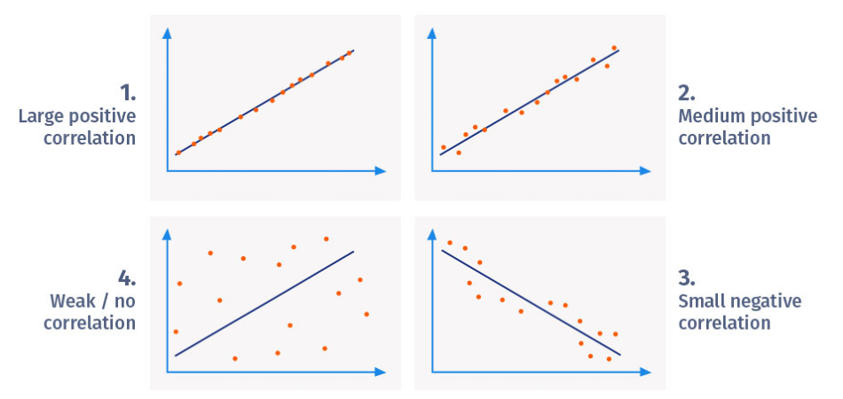

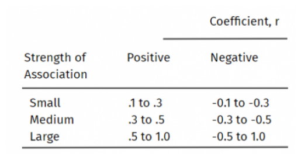

```python
plt.figure(figsize=(12, 6));
plt.imshow(plt.imread("corr1.png")), plt.axis("off"), plt.show();
plt.imshow(plt.imread("corr2.png")), plt.axis("off"), plt.show();
```

```python
correlations = df_dataset[["Survived", "Pclass", "Age", "SibSp", "Parch", "Fare"]].corr()
display.display(correlations)
```

|  | Survived | Pclass | Age | SibSp | Parch | Fare |
| --- | --- | --- | --- | --- | --- | --- |
| Survived | 1.000000 | -0.338481 | -0.077221 | -0.035322 | 0.081629 | 0.257307 |
| Pclass | -0.338481 | 1.000000 | -0.369226 | 0.083081 | 0.018443 | -0.549500 |
| Age | -0.077221 | -0.369226 | 1.000000 | -0.308247 | -0.189119 | 0.096067 |
| SibSp | -0.035322 | 0.083081 | -0.308247 | 1.000000 | 0.414838 | 0.159651 |
| Parch | 0.081629 | 0.018443 | -0.189119 | 0.414838 | 1.000000 | 0.216225 |
| Fare | 0.257307 | -0.549500 | 0.096067 | 0.159651 | 0.216225 | 1.000000 |

**Nhận xét**: Một số cặp biến có mức độ tương quan đáng chú ý:

- (Survived, Pclass) = -0.338 → Mối tương quan âm vừa phải, thể hiện hành khách ở hạng vé cao (Pclass nhỏ) có tỷ lệ sống sót cao hơn.
- (Survived, Fare) = 0.257 → Mối tương quan dương nhẹ, gợi ý rằng giá vé cao (tức hạng vé tốt) thường đi kèm khả năng sống sót cao hơn.
- (SibSp, Parch) = 0.415 → Cho thấy mối quan hệ dương giữa số anh chị em/vợ chồng và số cha mẹ/con cái đi cùng — tức những hành khách đi cùng gia đình thường có cả hai chỉ số này cao hơn.
- Các cặp biến còn lại như (Survived, Age) hay (Fare, Age) có hệ số tương quan nhỏ (< 0.1), cho thấy mối liên hệ yếu hoặc gần như không đáng kể giữa tuổi, giá vé và khả năng sống sót.

### 3.2. Hiển thị dữ liệu (Visualize Data) - Graphic Approach

#### (1) Hiển thị trên từng tính chất đơn (Univariate Plots)

##### Survived (Class Label)

```
Survived
0    549
1    342
Name: count, dtype: int64
```

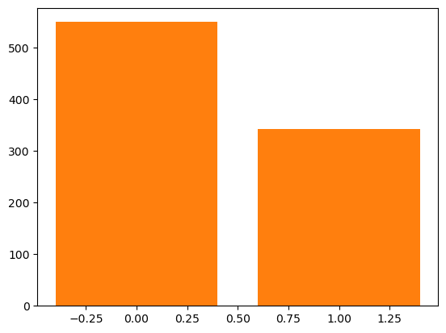

```python
# bar chart
counts = df_dataset["Survived"].value_counts()
plt.bar(counts.index, counts.values)
print(counts)
plt.show()
```

**Nhận xét**:

- Dữ liệu cần phân loại gồm 2 lớp: 0 tử vong, 1 sống sót
- Tỉ lệ phân bố không cân bằng vì khoảng 38.4% hành khách sống sót, 61,6% tử vong
- Tuy mức chênh lệch không quá lớn, nhưng lớp sống sót vẫn ít hơn đáng kể, do đó khi huấn luyện mô hình cần theo dõi độ chính xác theo từng lớp (class-wise performance) để tránh bias về phía lớp đa số.

##### Box and whisker plots

- So sánh các trung vị (median) tương ứng của mỗi ô hộp (box plot). Nếu đường trung vị của một ô hộp nằm bên ngoài ô của một ô hộp so sánh, thì có thể có sự khác biệt giữa hai nhóm.
- So sánh chiều dài hộp để kiểm tra cách dữ liệu được phân tán giữa mỗi mẫu. Hộp càng dài thì dữ liệu càng phân tán. Dữ liệu càng nhỏ càng ít bị phân tán.
- Một ngoại lệ (outlier) được định nghĩa là một điểm dữ liệu nằm bên ngoài phần rìa (whiskers) của ô hộp.
- Kiểm tra hướng lệch của dữ liệu (cân đối, các phần tử tập trung trái, phải).
  - Median ở giữa hộp và râu (whiskers) ở hai bên như nhau thì phân bố là đối xứng.
  - Median ở gần đáy hộp hơn và nếu râu ngắn hơn ở đầu dưới của hộp, thì phân phối là lệch dương (lệch phải).
  - Median ở gần đầu hộp hơn và nếu râu ngắn hơn ở đầu trên của hộp, thì phân bố bị lệch âm (lệch trái).

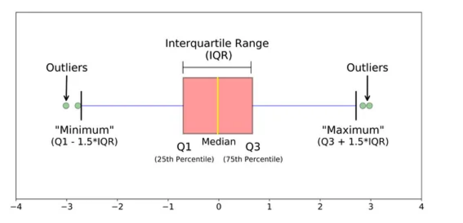

```python
plt.figure(figsize=(12, 6)), plt.imshow(plt.imread("boxplots.png")), plt.axis("off"), plt.show();
```

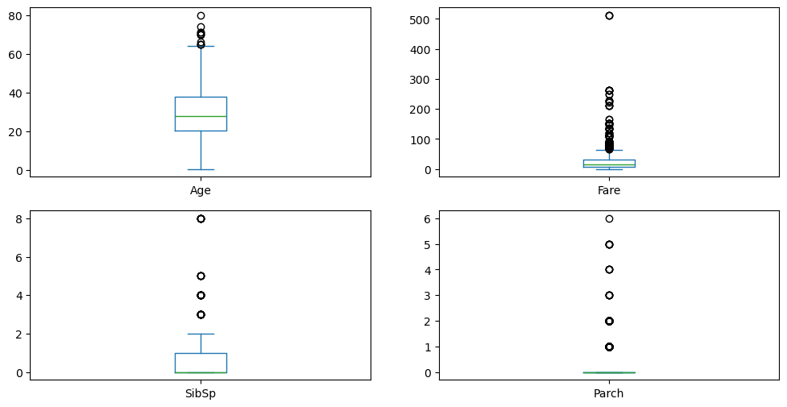

```python
cols = ["Age", "Fare", "SibSp", "Parch"]
df_dataset[cols].plot(kind="box", subplots=True, layout=(2, 2),
                              sharex=False, sharey=False, figsize=(12, 6))
plt.show()
```

**Nhận xét**:

- Age: Phân bố tương đối cân bằng, trung vị (median) khoảng 28–30 tuổi. Một số giá trị ngoại lai nằm trên 60–80 tuổi, thể hiện sự hiện diện của hành khách lớn tuổi nhưng số lượng ít.
- Fare: Có phân phối rất lệch phải (right-skewed) với nhiều giá trị ngoại lệ ở mức cao. Phần lớn hành khách trả giá vé thấp (<100), trong khi một số ít hành khách hạng cao có vé lên tới hơn 500.
- SibSp (số anh/chị/em hoặc vợ/chồng đi cùng): Đa số hành khách đi một mình, chỉ một vài trường hợp có từ 3–8 người đi cùng.
- Parch (số cha/mẹ/con đi cùng): Phần lớn hành khác đi một mình, chỉ một số nhỏ có tới 5–6 người thân đi cùng.
- Nhìn chung, các giá trị ngoại lệ xuất hiện rõ nhất ở biến Fare, kế đến là Age, còn SibSp và Parch có phân bố tập trung gần 0.

#### (2) Hiển thị nhiều tính chất (Multivariate Plots) using comparison graphs

#### Correlogram

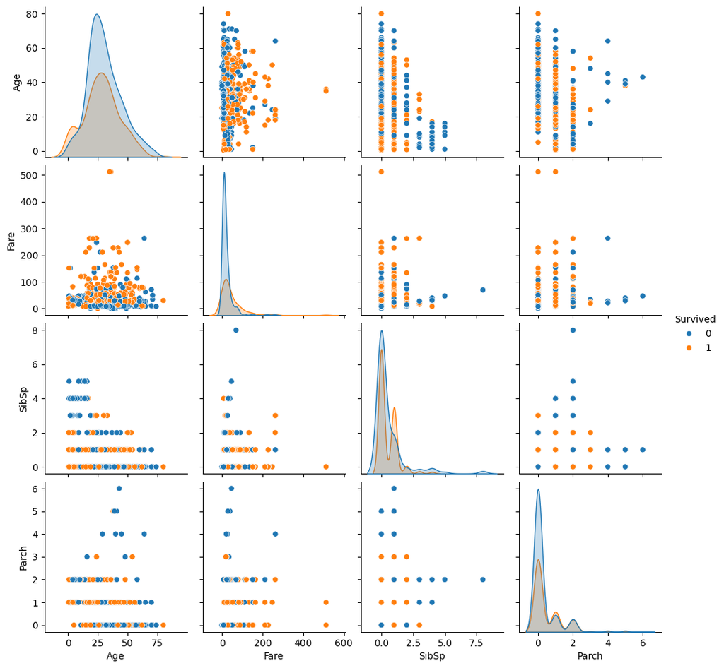

```python
numeric_cols = ["Age", "Fare", "SibSp", "Parch", "Survived"]

sns.pairplot(df_dataset[numeric_cols], hue="Survived")
plt.show()
```

**Nhận xét**:

- Fare: Những hành khách sống sót (màu cam) thường có giá vé cao hơn, thể hiện ảnh hưởng rõ rệt của điều kiện hạng vé đến khả năng sống sót.
- Age: Phân bố của tuổi giữa hai nhóm khá tương đồng, tuy nhiên nhóm trẻ hơn có xu hướng sống sót cao hơn một chút.
- Không có mối quan hệ tuyến tính mạnh giữa các cặp biến (Age–Fare, Age–SibSp, Fare–Parch) tuy nhiên ta có thể thấy các cụm điểm riêng biệt phản ánh đặc trưng của nhóm sống sót và không sống sót.

#### Heatmap

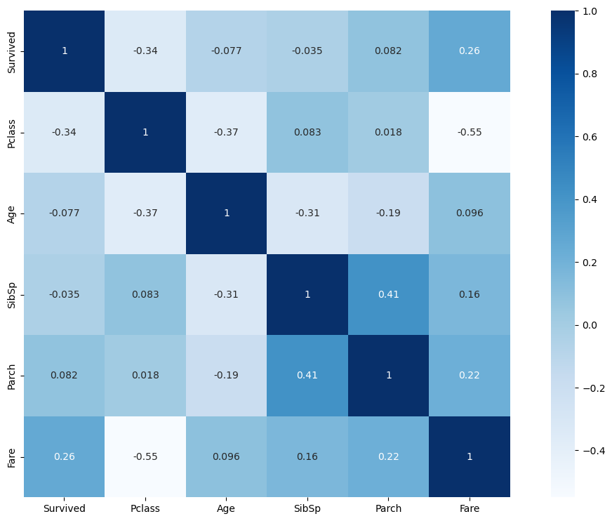

```python
numeric_cols = ["Survived", "Pclass", "Age", "SibSp", "Parch", "Fare"]

plt.figure(figsize=(15, 9))
sns.heatmap(df_dataset[numeric_cols].corr(method='pearson'), cmap='Blues', annot=True, square=True)
plt.show()
```

**Nhận xét**: Một số cặp biến có mức độ tương quan đáng chú ý:

- (Survived, Pclass) = -0.338 → Mối tương quan âm vừa phải, thể hiện hành khách ở hạng vé cao (Pclass nhỏ) có tỷ lệ sống sót cao hơn.
- (Survived, Fare) = 0.257 → Mối tương quan dương nhẹ, gợi ý rằng giá vé cao (tức hạng vé tốt) thường đi kèm khả năng sống sót cao hơn.
- (SibSp, Parch) = 0.415 → Cho thấy mối quan hệ dương giữa số anh chị em/vợ chồng và số cha mẹ/con cái đi cùng — tức những hành khách đi cùng gia đình thường có cả hai chỉ số này cao hơn.
- Các cặp biến còn lại như (Survived, Age) hay (Fare, Age) có hệ số tương quan nhỏ (< 0.1), cho thấy mối liên hệ yếu hoặc gần như không đáng kể giữa tuổi, giá vé và khả năng sống sót.